# Urban/Suburban Poverty Analysis using ACS data

BGD on a logit model - predict percent of population in poverty given other percentage variables for census block groups in Iowa and Nebraska. This is an exporatory project that aims to identify links between poverty in urban and suburban enviornments, wtih respect to their differences and neighborhoods which are difficult to model

```python
import pandas as pd
import numpy as np
from scipy.special import gamma
import matplotlib.pyplot as plt
import seaborn as sns
%matplotlib inline

df = pd.read_excel('/Users/jonahwilliams/Downloads/census blck_2014.xlsx').fillna(0)

def removeInf(x):
    if x == float('inf'):
        x = 0
    return x

urban = df[[col for col in df.columns if 'pct' in col and 'MOE' not in col and "CEN" not in col]][df["area code"]==1]
urban = urban.applymap(lambda x: float(x)/100).reset_index().drop('index',axis=1)
urban = urban.drop(['pct_Females_ACS_08_12',
                              'pct_Pop_65plus_ACS_08_12',
                              'pct_Pov_Univ_ACS_08_12',
                              'pct_Pop_5yrs_Over_ACS_08_12',
                              'pct_Rel_Under_6_ACS_08_12',
                              'pct_Pop_1yr_Over_ACS_08_12'],
                               axis=1)

suburban = df[[col for col in df.columns if 'pct' in col and 'MOE' not in col and "CEN" not in col]][df["area code"]==2]
suburban = suburban.applymap(lambda x: float(x)/100).reset_index().drop('index',axis=1)
suburban = suburban.drop(['pct_Females_ACS_08_12',
                              'pct_Pop_65plus_ACS_08_12',
                              'pct_Pov_Univ_ACS_08_12',
                              'pct_Pop_5yrs_Over_ACS_08_12',
                              'pct_Rel_Under_6_ACS_08_12',
                              'pct_Pop_1yr_Over_ACS_08_12'],
                               axis=1)
param_lookup = {}
param_mapper = {}
for i, col in enumerate(suburban.columns):
    param_lookup[i] = " ".join(col.split("_")[0:-3])
    param_mapper[col] = i
```

Here we remove non-percent columns and remove some which are redundent with other data. We also split the data into urban and suburban based on geocoding information

```python
def logit(data, parameters, bias):
    return 1 / (1 + np.exp(-(np.dot(data, parameters) + bias)))

y = suburban[["pct_Prs_Blw_Pov_Lev_ACS_08_12"]].values
X = suburban[[col for col in suburban.columns if col != "pct_Prs_Blw_Pov_Lev_ACS_08_12"]].values

sub_parameters = []
sub_biases = []
sub_errors = []
for i in range(100):
    error = []
    param = np.random.normal(0, 0.01, (len(X[0])))
    bias = 0
    for i in xrange(1000):
        if (i % 100 == 0):
            error.append(np.mean((logit(X, param, bias) - y[0::, 0])**2))
        param += -0.01 * np.dot((logit(X, param, bias) - y[0::, 0]) * (1 - logit(X, param, bias) * logit(X, param, bias)), X)
        bias += -0.01 * np.mean((logit(X, param, bias) - y[0::, 0]) * (1 - logit(X, param, bias) * logit(X, param, bias)))
    sub_errors.append(error)
    sub_parameters.append(param)
    sub_biases.append(bias)

y = urban[["pct_Prs_Blw_Pov_Lev_ACS_08_12"]].values
X = urban[[col for col in urban.columns if col != "pct_Prs_Blw_Pov_Lev_ACS_08_12"]].values

urb_parameters = []
urb_biases = []
urb_errors = []
for i in range(100):
    error = []
    param = np.random.normal(0, 0.01, (len(X[0])))
    bias = 0
    for i in xrange(1000):
        if (i % 100 == 0):
            error.append(np.mean((logit(X, param, bias) - y[0::, 0])**2))
        param += -0.01 * np.dot((logit(X, param, bias) - y[0::, 0]) * (1 - logit(X, param, bias) * logit(X, param, bias)), X)
        bias += -0.01 * np.mean((logit(X, param, bias) - y[0::, 0]) * (1 - logit(X, param, bias) * logit(X, param, bias)))
    urb_errors.append(error)
    urb_parameters.append(param)
    urb_biases.append(bias)
```

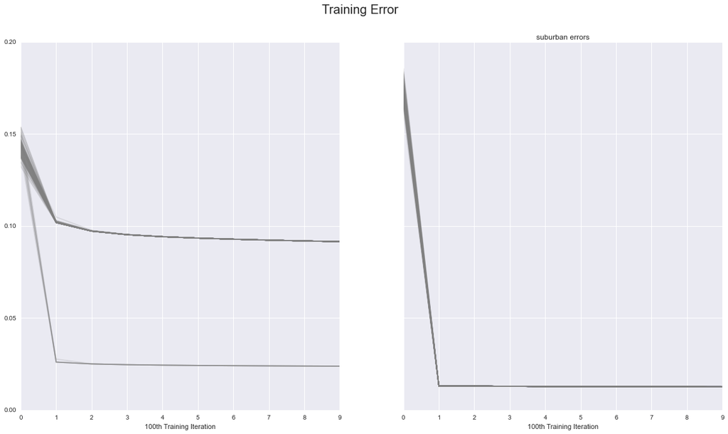

```python
fig, ax = plt.subplots(1, 2, sharex=False, sharey=True)
fig.set_size_inches(20,10.5)
fig.suptitle("Training Error", fontsize=20)


for item in urb_errors:
    ax[0].plot(item, color="grey", alpha=0.2)
ax[0].set_xlabel("100th Training Iteration")
plt.title("urban errors")

for item in sub_errors:
    ax[1].plot(item, color="grey", alpha=0.2)
ax[1].set_xlabel("100th Training Iteration")
plt.title("suburban errors")
plt.show()
```

Above we have the training error on each of the 100 repeats of the batch gradient descent procedure. Note the clear local minimum that some of the urban training data is stuck on. This will also be apparebt on a graph of the parameter values below

```python
urb_param = dict((i,[]) for i in range(len(X[0])))
sub_param = dict((i,[]) for i in range(len(X[0])))
mean_urb_param = dict((i,[]) for i in range(len(X[0])))
mean_sub_param = dict((i,[]) for i in range(len(X[0])))
for i in range(100):
    for j in range(len(X[0])):
        sub_param[j].append(sub_parameters[i][j])
        urb_param[j].append(urb_parameters[i][j])

for key, value in urb_param.items():
    mean_urb_param[key] = np.mean(value)

for key, value in sub_param.items():
    mean_sub_param[key] = np.mean(value)
```

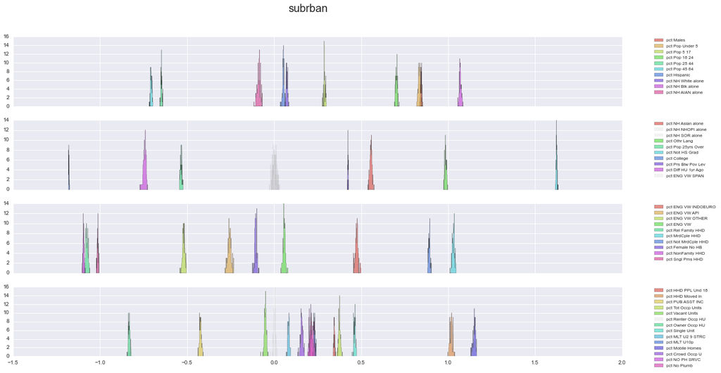

```python
param_list = sub_param
fig, ax = plt.subplots(4, 1, sharex=True, sharey=False)
colors = sns.color_palette("hls", 10)
fig.set_size_inches(20,10.5)
fig.suptitle('subrban', fontsize=20)
for i in range(0, 10):
    if np.mean(param_list[i]) > 0 and np.percentile(param_list[i], 5) < 0:
        ax[0].hist(param_list[i], alpha=0.1, histtype="stepfilled", color="grey", label=param_lookup[i], bins=25)
    elif np.mean(param_list[i]) < 0 and np.percentile(param_list[i], 95) > 0:
        ax[0].hist(param_list[i], alpha=0.1, histtype="stepfilled", color="grey", label=param_lookup[i], bins=25)
    else:
        ax[0].hist(param_list[i], alpha=0.7, histtype="stepfilled", color=colors[i], label=param_lookup[i], bins=25)
    ax[0].legend(prop={'size':8}, bbox_to_anchor=(1.05, 1), loc=2, borderaxespad=0.)



for i in range(10, 20):
    if np.mean(param_list[i]) > 0 and np.percentile(param_list[i], 5) < 0:
        ax[1].hist(param_list[i], alpha=0.1, histtype="stepfilled", color="grey", label=param_lookup[i], bins=25)
    elif np.mean(param_list[i]) < 0 and np.percentile(param_list[i], 95) > 0:
        ax[1].hist(param_list[i], alpha=0.1, histtype="stepfilled", color="grey", label=param_lookup[i], bins=25)
    else:
        ax[1].hist(param_list[i], alpha=0.7, histtype="stepfilled", color=colors[i - 10], label=param_lookup[i], bins=25)
    ax[1].legend(prop={'size':8}, bbox_to_anchor=(1.05, 1), loc=2, borderaxespad=0.)


for i in range(20, 30):
    if np.mean(param_list[i]) > 0 and np.percentile(param_list[i], 5) < 0:
        ax[2].hist(param_list[i], alpha=0.1, histtype="stepfilled", color="grey", label=param_lookup[i], bins=25)
    elif np.mean(param_list[i]) < 0 and np.percentile(param_list[i], 95) > 0:
        ax[2].hist(param_list[i], alpha=0.1, histtype="stepfilled", color="grey", label=param_lookup[i], bins=25)
    else:
        ax[2].hist(param_list[i], alpha=0.7, histtype="stepfilled", color=colors[i - 20], label=param_lookup[i], bins=25)
    ax[2].legend(prop={'size':8}, bbox_to_anchor=(1.05, 1), loc=2, borderaxespad=0.)

colors = sns.color_palette("hls", 15)
for i in range(30, 44):
    if np.mean(param_list[i]) > 0 and np.percentile(param_list[i], 5) < 0:
        ax[3].hist(param_list[i], alpha=0.1, histtype="stepfilled", color="grey", label=param_lookup[i], bins=25)
    elif np.mean(param_list[i]) < 0 and np.percentile(param_list[i], 95) > 0:
        ax[3].hist(param_list[i], alpha=0.1, histtype="stepfilled", color="grey", label=param_lookup[i], bins=25)
    else:
        ax[3].hist(param_list[i], alpha=0.7, histtype="stepfilled", color=colors[i - 30], label=param_lookup[i], bins=25)
    ax[3].legend(prop={'size':8}, bbox_to_anchor=(1.05, 1), loc=2, borderaxespad=0.)
```

A histogram of the paramter values obtained from the BGD procedure. For the final model the mean value will be used. Paramters approximately centered on 0 are grey. Negative values can be roughly interpreted as a negative contribution to povery rate (that is decreasing poverty) and positive values as increasing poverty rate. There are several obvious examples, with percentage of monbile homes and percentage not high school educated contributing highly.

Interpretation of these parameters beyond correlationationary statements are cautioned against.

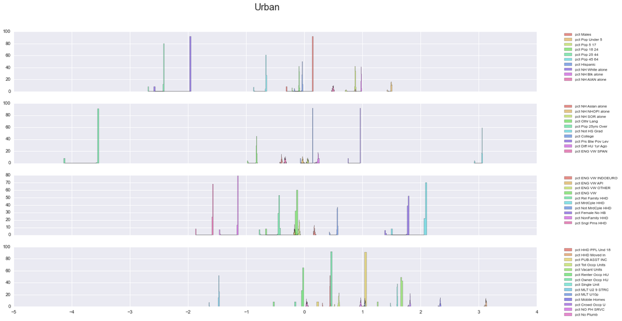

```python
param_list = urb_param
fig, ax = plt.subplots(4, 1, sharex=True, sharey=False)
colors = sns.color_palette("hls", 10)
fig.set_size_inches(20,10.5)
fig.suptitle('Urban', fontsize=20)
for i in range(0, 10):
    ax[0].hist(param_list[i], alpha=0.7, histtype="stepfilled", color=colors[i], label=param_lookup[i], bins=25)
    ax[0].legend(prop={'size':8}, bbox_to_anchor=(1.05, 1), loc=2, borderaxespad=0.)


for i in range(10, 20):
    ax[1].hist(param_list[i], alpha=0.7, histtype="stepfilled", color=colors[i - 10], label=param_lookup[i], bins=25)
    ax[1].legend(prop={'size':8}, bbox_to_anchor=(1.05, 1), loc=2, borderaxespad=0.)


for i in range(20, 30):
    ax[2].hist(param_list[i], alpha=0.7, histtype="stepfilled", color=colors[i - 20], label=param_lookup[i], bins=25)
    ax[2].legend(prop={'size':8}, bbox_to_anchor=(1.05, 1), loc=2, borderaxespad=0.)

colors = sns.color_palette("hls", 15)
for i in range(30, 44):
    ax[3].hist(param_list[i], alpha=0.7, histtype="stepfilled", color=colors[i - 30], label=param_lookup[i], bins=25)
    ax[3].legend(prop={'size':8}, bbox_to_anchor=(1.05, 1), loc=2, borderaxespad=0.)
```

Here the local minimum structure of the urban data is apparent in the bimodal peaks of the parameters estimates. Essentially we have two slightly different models, depending on which valley the BGD procedure terminated at. instead of using mean estimates, the mode of these histograms will be used in the final model

# Residual Analysis

Because the model was chosen and fit on all of the data, we can not get an unbiased estimate of out of sample error. This was outside the scope of the project however, especially due to the small amount of data. Instead we will use the optimal parameter estimates and look for local co-occurance of high residual values, essentailly identifying neighborhoods with undocumented but significant local explanatory variables.

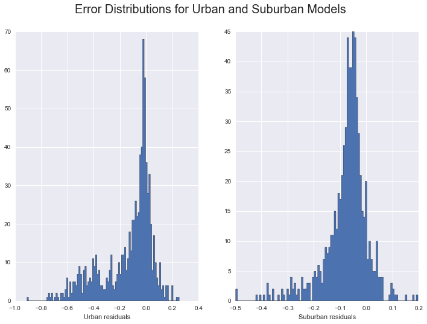

```python
def calc_mode(x):
    '''Approximates the mode of the data by resampling and using numpy.mode'''
    from scipy.stats.mstats import mode
    return mode(np.random.choice(x, 100000))[0]

fig, ax = plt.subplots(1, 2)
fig.set_size_inches(12, 8)
urban_model = np.zeros(len(X[0]))
for i in range(len(X[0])):
    urban_model[i] = calc_mode(np.array(urb_parameters)[0::, i])
urban_bias = calc_mode(urb_biases)
y = urban[["pct_Prs_Blw_Pov_Lev_ACS_08_12"]].values
X = urban[[col for col in urban.columns if col != "pct_Prs_Blw_Pov_Lev_ACS_08_12"]].values

ax[0].hist(y[0::, 0] - logit(X, urban_model, urban_bias), histtype="stepfilled", bins=100)
ax[0].set_xlabel("Urban residuals")


suburban_model = np.zeros(len(X[0]))
for i in range(len(X[0])):
    suburban_model[i] = np.mean(np.array(sub_parameters)[0::, i])
suburban_bias = np.mean(sub_biases)
y = suburban[["pct_Prs_Blw_Pov_Lev_ACS_08_12"]].values
X = suburban[[col for col in suburban.columns if col != "pct_Prs_Blw_Pov_Lev_ACS_08_12"]].values

ax[1].hist(y[0::, 0] - logit(X, suburban_model, suburban_bias), histtype="stepfilled", bins=100)
ax[1].set_xlabel("Suburban residuals")
fig.suptitle('Error Distributions for Urban and Suburban Models', fontsize=20)
plt.show()
```

Here we have a distribution of the residuals from the two models, where overprediction of poverty results in a negative value and underprediction results in a positive value. Note the clear bimodal struture in the urban residuals. There is a subgroup for which our model is not correct, in the sense that it consistently overpredicts the poverty percentages.

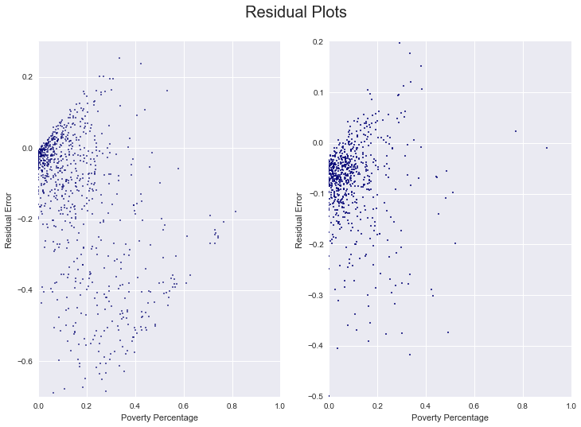

```python
fig, ax = plt.subplots(1, 2)
fig.set_size_inches(12, 8)

y = urban[["pct_Prs_Blw_Pov_Lev_ACS_08_12"]].values
X = urban[[col for col in urban.columns if col != "pct_Prs_Blw_Pov_Lev_ACS_08_12"]].values

urban_residual =  y[0::, 0] - logit(X, urban_model, urban_bias)
ax[0].scatter(y[0::, 0],urban_residual, s=2)
ax[0].set_xlim(0, 1)
ax[0].set_ylim(-0.7, 0.3)
ax[0].set_xlabel("Poverty Percentage")
ax[0].set_ylabel("Residual Error")

y = suburban[["pct_Prs_Blw_Pov_Lev_ACS_08_12"]].values
X = suburban[[col for col in suburban.columns if col != "pct_Prs_Blw_Pov_Lev_ACS_08_12"]].values

suburban_residual = y[0::, 0] - logit(X, suburban_model, suburban_bias)
ax[1].scatter(y[0::, 0], suburban_residual, s=3)
ax[1].set_xlim(0, 1)
ax[1].set_ylim(-0.5, 0.2)
ax[1].set_xlabel("Poverty Percentage")
ax[1].set_ylabel("Residual Error")
fig.suptitle('Residual Plots', fontsize=20)
plt.show()
```

```python
from json import loads
from descartes import PolygonPatch

json_data = loads(open("censusBlockData.json","r").read())['features']
df.index = df.GIDBG
lookup = df[[col for col in df.columns if 'pct' in col and 'MOE' not in col and "CEN" not in col]]\
        .applymap(lambda x: float(x)/100)\
        .drop(['pct_Females_ACS_08_12',
              'pct_Pop_65plus_ACS_08_12',
              'pct_Pov_Univ_ACS_08_12',
              'pct_Pop_5yrs_Over_ACS_08_12',
              'pct_Rel_Under_6_ACS_08_12',
              'pct_Pop_1yr_Over_ACS_08_12'],
               axis=1)

for h in range(len(json_data)):
    if json_data[h]['properties']['area code'] == 1:
        filtered = lookup[lookup.index == int(json_data[h]['properties']['GEOID'])]
        res = filtered[["pct_Prs_Blw_Pov_Lev_ACS_08_12"]].values[0] - logit(filtered[[col for col in filtered.columns if col != "pct_Prs_Blw_Pov_Lev_ACS_08_12"]].values[0],
              urban_model, urban_bias)
        json_data[h]['properties']['residual'] = res
    if json_data[h]['properties']['area code'] == 2:
        filtered = lookup[lookup.index == int(json_data[h]['properties']['GEOID'])]
        res = filtered[["pct_Prs_Blw_Pov_Lev_ACS_08_12"]].values[0] - logit(filtered[[col for col in filtered.columns if col != "pct_Prs_Blw_Pov_Lev_ACS_08_12"]].values[0],
              suburban_model, suburban_bias)
        json_data[h]['properties']['residual'] = res
```

```python
# Source : Colorbrewer2.org
colormap = ["#b2182b", "#ef8a62", "#fddbc7", "#f7f7f7", "#d1e5f0", "#67a9cf", "#2166ac"]

urban_std = np.std(urban_residual)
suburban_std = np.std(suburban_residual)

def closest_breakpoint(x, std):
    if (x > 0 - std) and (x < 0 + std):
        return 3
    elif (x >= 0 + std) and (x < 0 + 2*std):
        return 4
    elif (x >= 0 + 2*std) and (x < 0 + 3*std):
        return 5
    elif (x >= 0 + 3*std):
        return 6
    elif (x <= 0 - std) and (x > 0 - 2*std):
        return 2
    elif (x <= 0 - 2*std)and (x > 0 - 3*std):
        return 1
    else:
        return 0
```

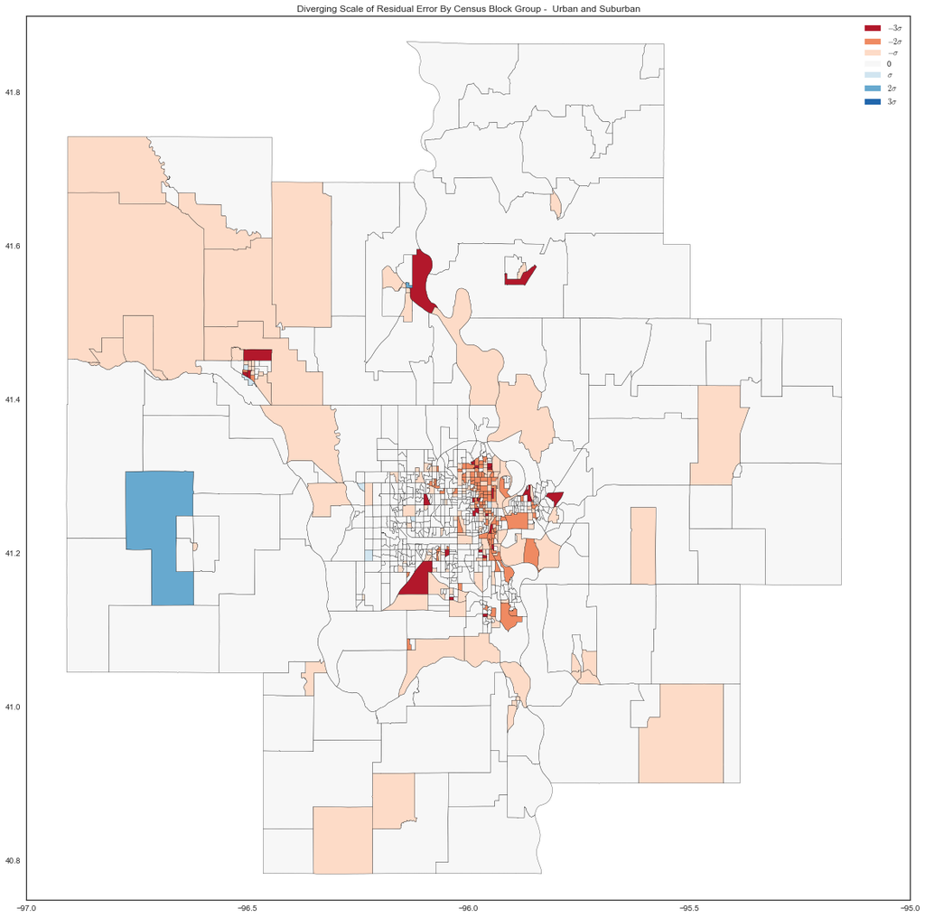

```python
sns.set_style("white")
import matplotlib.patches as mpatches
fig = plt.figure(figsize=(20, 20))
ax = fig.gca()
for h in range(len(json_data)):
    if json_data[h]['properties']['area code'] == 1:
        poly = {'type': 'Polygon', 'coordinates': json_data[h]["geometry"]["coordinates"]}
        fill = closest_breakpoint(json_data[h]['properties']['residual'], urban_std)
        ax.add_patch(PolygonPatch(poly,ec="black",fc=colormap[fill], alpha=1, zorder=2 ))
    if json_data[h]['properties']['area code'] == 2:
        fill = closest_breakpoint(json_data[h]['properties']['residual'], suburban_std)
        poly = {'type': 'Polygon', 'coordinates': json_data[h]["geometry"]["coordinates"]}
        ax.add_patch(PolygonPatch(poly,ec="black",fc=colormap[fill],alpha=1, zorder=2 ))
ax.set_xlim(-97, -95)
ax.set_ylim(40.75, 41.9)


patch1 = mpatches.Patch(color=colormap[0], label='$-3\sigma$')
patch2 = mpatches.Patch(color=colormap[1], label='$-2\sigma$')
patch3 = mpatches.Patch(color=colormap[2], label='$-\sigma$')
patch4 = mpatches.Patch(color=colormap[3], label='0')
patch5 = mpatches.Patch(color=colormap[4], label='$\sigma$')
patch6 = mpatches.Patch(color=colormap[5], label='$2\sigma$')
patch7 = mpatches.Patch(color=colormap[6], label='$3\sigma$')

plt.legend(handles=[patch1, patch2, patch3, patch4, patch5, patch6, patch7])

plt.title("Diverging Scale of Residual Error By Census Block Group -  Urban and Suburban")
plt.show()
```

Above we have a map of the omaha metro area, with color coding the standard deviations of the error from 0 residual error. We can identify the model has a poor fit in north omaha for starters.